# Facemask detection using `Convolutional Neural Network` in `Python`

The `facemask lite` dataset on `Kaggle` contains `GAN-2` generated images of people with masks and without masks. Using that dataset, we trained a `Convolutional Neural Network` (CNN) to detect when someone is wearing a mask.  
We start by loading and preparing the dataset; then, we visualize the distribution of the images in the dataset.  
Next, we `build` the CNN model, `train` the model, then `evaluate` it.  
Finally, we apply the model to `predict` whether someone is wearing a mask or not.  
Keywords:  
`Data`  
`Pytorch`  
`Convolutional Neural Network` (CNN)  
`Deep Learning`  
`Facemask`

### Preliminary steps

1. Download face mask lite dataset from kaggle  
   Dataset source: https://www.kaggle.com/prasoonkottarathil/face-mask-lite-dataset
2. Unzip into folder named "data"
3. Separate data matching faces `with mask` and `without mask` into `training`, `validation`, and `testing` sets.

## `Kernel` preparation and `module` import

### Loading all nessesary `modules` and `libraries`.

```python
# module import
import pandas as pd
import numpy as np
import matplotlib.pyplot as plt
import seaborn as sns

import dill
import torch
from torchvision import datasets, transforms, utils
import torchvision
import torch.nn as nn
import torch.optim as optim
import torch.nn.functional as F

from sklearn.metrics import classification_report, confusion_matrix
```

### Using `dill` to save and load the kernel so not to loose trained model after kernel restart or system reboot.

```python
# Load the saved session
#dill.load_session('notebook_env.db')
```

# Dataset preparation and data loading

### Loading data directories.

```python
train_data_dir = "data/train_dataset"
val_data_dir = "data/validation_dataset"
test_data_dir = "data/test_dataset"
save_data_dir = "data/save_dataset"
full_data_dir = "data/full_dataset"
```

### Defining training variables.

```python
batch_size_train = 64
batch_size_test = 1
batch_size = 1
image_size = 1024
num_epochs = 5
```

### Setting the GPU as the device training the model. Requires an NVIDIA GPU to be available.

```python
# Using GPU for faster training
device = "cuda" if torch.cuda.is_available() else "cpu"
kwargs = {'num_workers': 15, 'pin_memory': True} if device=='cuda' else {}
device
```

```
'cuda'
```

```python
# System hardware profile
torch.cuda.get_device_name(0)
```

```
'NVIDIA GeForce GTX 1060'
```

### Setting data transformations for training, validation, and testing dataset.

```python
# Training dataset
train_transform = transforms.Compose([
    transforms.Resize(512),
    transforms.RandomRotation(30),
    transforms.RandomHorizontalFlip(),
    transforms.ToTensor(),
    ])

# Validation dataset
val_transform = transforms.Compose([
    transforms.Resize(512),
    transforms.ToTensor(),
    ])

# Testing dataset
test_transform = transforms.Compose([
    transforms.Resize(512),
    transforms.ToTensor(),
    ])

# saved dataset
save_transform = transforms.Compose([
    transforms.Resize(512),
    transforms.ToTensor(),
    ])

# full dataset
full_transform = transforms.Compose([
    transforms.ToTensor(),
    ])
```

### Applying the transforms to the data.

```python
# Training data
train_data = datasets.ImageFolder(train_data_dir, transform=train_transform)

# Validation data
val_data = datasets.ImageFolder(val_data_dir, transform=val_transform)

# Testing data
test_data = datasets.ImageFolder(test_data_dir, transform=test_transform)

# Testing data
save_data = datasets.ImageFolder(save_data_dir, transform=save_transform)

# full data
full_data = datasets.ImageFolder(full_data_dir, transform=full_transform)
```

### Loading the data to the `dataloader`.

```python
# Loading Training data
train_loader = torch.utils.data.DataLoader(train_data, batch_size = batch_size_train, shuffle=True, **kwargs)

# Loading Validation data
val_loader = torch.utils.data.DataLoader(val_data, batch_size = batch_size, **kwargs)

# Loading Testing data
test_loader = torch.utils.data.DataLoader(test_data, batch_size = batch_size_test, **kwargs)
```

# `Visualization` of the `distribution` of the full dataset

### Class and ID mapping of output.

Label `0` indicates the presence of a `facemask`, and label `1` indicates the absence of a `facemask`.

```python
# Returns the class id present in the data
full_data.class_to_idx
```

```
{'with_mask': 0, 'without_mask': 1}
```

```python
# construct a reverse of this dictionary, mapping of ID to class.
idx2class = {v: k for k, v in full_data.class_to_idx.items()}
```

### Visualization function

Define a function that takes in a `dataset object` and returns a dictionary that contains the count of `class` samples

```python
# Get class distribution
def get_class_distribution(dataset_obj):
    count_dict = {k:0 for k,v in dataset_obj.class_to_idx.items()}
    for _, label_id in dataset_obj:
        label = idx2class[label_id]
        count_dict[label] += 1
    return count_dict

# Plot distribution
def plot_from_dict(dict_obj, plot_title, **kwargs):
    return sns.barplot(data = pd.DataFrame.from_dict([dict_obj]).melt(), x = "variable", y="value", hue="variable", **kwargs).set_title(plot_title)


plt.figure(figsize=(15,8))
plot_from_dict(get_class_distribution(full_data), plot_title="Entire Dataset (before train/val/test split)")
```

[figure not shown]

### Define a function to display the images

```python
# Function to show images
def imshow(img):
     img = img / 2 + 0.5
     npimg = img.numpy()
     plt.imshow(np.transpose(npimg, (1, 2, 0)))
     plt.show()
```

### Retrieve the images and labels from the loader and display a training image batch.

```python
# Retreive images
images, labels = next(iter(train_loader))

# Display images
imshow(torchvision.utils.make_grid(images))
```

[figure not shown]

### Exploring an image, checking the `dimentions`, and `labels`

```python
# Print first image dimentions
print(images[0].shape)

# Print first image label
print(labels[0])
```

```
torch.Size([3, 512, 512])
tensor(1)
```

```python
# Save the session
dill.dump_session('notebook_env.db')
```

# Building the CNN with the `sequential` module

Our `CNN` is composed of three convolution layers, three `RELu` activation layers, three `batch normalization` layers and two `maxpooligng` layers for feature extraction. The fully connected (FC) layer has three linear layers and two RELu activation layer.  
The architecture of our CNN is as follow.  
2 X `convolution` + `maxpooligng` + `RELu activation` + `batch normalization`.  
1 X `convolution` + `RELu activation` + `batch normalization`.  
2 X `FC layers` + `RELu activation`.  
1 X `FC layer`. Our CNN also implemented the `Sequential` module. We use one sequential module for the feature extraction and another sequential module for the fully connected layers.  
Originally our neural network model had more layers. But because of hardware resource limitations and long training time, the neural layers have been reduced to the one described above.

### The `sequential` module - declaring the module and the `forward()` method

```python
class Net(nn.Module):
    def __init__(self, num_classes=2):
        super(Net, self).__init__()
        # Variables
        k_size = 3
        stride = 1
        padding = 1
        # Declare all the layers for feature extraction
        self.features = nn.Sequential(
            # First convolutional layers
            nn.Conv2d(in_channels=3, out_channels=10, kernel_size=k_size, stride=stride, padding=padding),
            # Max pooling layer
            nn.MaxPool2d(kernel_size=2, stride=2),
            # ReLU nonlinearity
            nn.ReLU(inplace=True),
            # Batch Normalization
            nn.BatchNorm2d(num_features = 10),
            # Second convolutional layers
            nn.Conv2d(in_channels=10, out_channels=32, kernel_size=k_size, stride=stride, padding=padding),
            # Max pooling layer
            nn.MaxPool2d(kernel_size=2, stride=2),
            # ReLU nonlinearity
            nn.ReLU(inplace=True),
            # Batch Normalization
            nn.BatchNorm2d(num_features = 32),
            # Third convolutional layers
            nn.Conv2d(in_channels=32, out_channels=64, kernel_size=k_size, stride=stride, padding=padding),
            # ReLU nonlinearity
            nn.ReLU(inplace=True),
            # Batch Normalization
            nn.BatchNorm2d(num_features = 64),
            # Fourth convolutional layers
            # nn.Conv2d(in_channels=64, out_channels=128, kernel_size=k_size, stride=stride, padding=padding),
            # # Max pooling layer
            # nn.MaxPool2d(kernel_size=2, stride=2),
            # # ReLU nonlinearity
            # nn.ReLU(inplace=True),
            # # Batch Normalization
            # nn.BatchNorm2d(num_features = 128),
            # # Fith convolutional layers
            # nn.Conv2d(in_channels=128, out_channels=256, kernel_size=k_size, stride=stride, padding=padding),
            # # Max pooling layer
            # nn.MaxPool2d(kernel_size=2, stride=2),
            # # ReLU nonlinearity
            # nn.ReLU(inplace=True),
            # # Batch Normalization
            # nn.BatchNorm2d(num_features = 256)
        )
        # Declare all the layers for classification
        self.classifier = nn.Sequential(
            nn.Linear(128 * 128 * 64, 512),
            nn.ReLU(inplace=True),
            nn.Linear(512, 512),
            nn.ReLU(inplace=True),
            nn.Linear(512, num_classes)
        )

    # Forward method
    def forward(self, x):
        # Apply the feature extractor in the input
        x = self.features(x)
        # Squeeze the three spatial dimensions in one
        x = x.view(-1, 128 * 128 * 64)
        # Classify the images
        x = self.classifier(x)
        return x
```

# Training the model

### Optimizer with L2-regularization and Loss Function

```python
# Instantiate the network and move it to GPU
model = Net()
model.to(device)
# Instantiate the cross-entropy loss
criterion = nn.CrossEntropyLoss()

# Instantiate the Adam optimizer
optimizer = optim.Adam(model.parameters(), lr=3e-4, weight_decay=0.001)
```

```python
# Save the session
dill.dump_session('notebook_env.db')
```

```python
# Lets look at the model
for n, p in model.named_parameters():
    print(p.device, "", n)
```

```
cpu  features.0.weight
cpu  features.0.bias
cpu  features.3.weight
cpu  features.3.bias
cpu  features.4.weight
cpu  features.4.bias
cpu  features.7.weight
cpu  features.7.bias
cpu  features.8.weight
cpu  features.8.bias
cpu  features.10.weight
cpu  features.10.bias
cpu  classifier.0.weight
cpu  classifier.0.bias
cpu  classifier.2.weight
cpu  classifier.2.bias
cpu  classifier.4.weight
cpu  classifier.4.bias
```

```python
# keeping track of losses
train_losses = []
valid_losses = []

print("starting training.")

for epoch in range(num_epochs + 1):
    # keep-track-of-training-and-validation-loss
    train_loss = 0.0
    valid_loss = 0.0

    # Training the model
    model.train()
    for i, data in enumerate(train_loader, 0):
        # Get the inputs and moving data to GPU
        inputs, labels = data
        inputs = inputs.to(device)
        labels = labels.to(device)

        # Zero the parameter gradients
        optimizer.zero_grad()

        # Release GPU memory
        torch.cuda.empty_cache()

        # Compute the forward pass
        outputs = model(inputs)

        # Compute the loss function
        loss = criterion(outputs, labels)

        # Compute the gradients
        loss.backward()

        # Update the weights
        optimizer.step()

        # update training loss
        train_loss += loss.item() * inputs.size(0)

        print("Training in progress ...")

    # calculate average losses
    train_loss = train_loss/len(train_loader.sampler)
    train_losses.append(train_loss)

    # print training statistics
    print('Epoch: {} \tTraining Loss: {:.6f}'.format(epoch, train_loss))

print("Training completed")
```

Training in progress ...

Epoch: 1 Training Loss: 0.041914

Training in progress ...

Epoch: 2 Training Loss: 0.000001

Training in progress ...

Epoch: 3 Training Loss: 0.000000

Training in progress ...

. . .

Training in progress ...

Epoch: 5 Training Loss: 0.000000

Training completed

Note: Output Trimed for visualization.

```python
# Load the saved session
dill.load_session('notebook_env.db')
```

### Visualizing the training loss.

```python
plt.plot(train_losses, label='Training loss')
plt.xlabel("Epochs")
plt.ylabel("Loss")
plt.legend(frameon=False)
```

[figure not shown]

```python
# Save the session after training
dill.dump_session('notebook_env.db')
```

```python
# Release GPU memory
torch.cuda.empty_cache()
```

# Evaluating the model

We evaluate the model and print the final accuracy.

```python
correct, total = 0, 0
predictions = []

model.eval()

# Iterate over the data in the test_loader
for i, data in enumerate(val_loader, 0):

    # Get the image and label from data
    images, labels = data

    # Move data to GPU if available
    images = images.to(device)
    labels = labels.to(device)

    # Make a forward pass in the net with your image
    outputs = model(images)

    # Argmax the results of the net
    _, predicted = torch.max(outputs.data, 1)
    predictions.append(outputs)
    total += labels.size(0)
    correct += (predicted == labels).sum().item()

    # Print predictions
    if predicted == labels:
        print("Yipes, the net made the right prediction " + str(predicted))
    else:
        print("The net prediction was " + str(predicted) + ", but the correct label is: " + str(labels))

print("The testing set accuracy of the network is: %d %%" % (100 * correct / total))
```

Yipes, the net made the right prediction tensor([1])

Yipes, the net made the right prediction tensor([1])

Yipes, the net made the right prediction tensor([1])

. . .

Yipes, the net made the right prediction tensor([1])

The testing set accuracy of the network is: 100 %

Note: Output Trimed for visualization.

### The `accuracy` of the model is very high (100%). Overfitting could be a factor in play. We will need the testing phase with unseen data to confirm the performance of the model.

```python
# Save the session with dill
dill.dump_session('notebook_env.db')
```

```python
# Save the model
torch.save(model, "facemaskmodel.pth")
```

# Testing the model

After the training, we need to test how our model will perform with unseen data.  
Before the testing, we disable back-propagation during the inference stage with `torch.no_grad()`

```python
# Load the model
model = torch.load('facemaskmodel.pth')
```

```python
# Define a list that will hold our prediction for each batch.
label_pred = []
label_true = []
model.eval()
with torch.no_grad():
    for i, data in enumerate(test_loader, 0):
        # Get images and labels
        image_batch, true_label_batch = data

        # Sent to GPU
        image_batch.to(device)
        true_label_batch.to(device)

        # Make prediction
        label_test_pred = model(image_batch)

        _, label_pred_tag = torch.max(label_test_pred, dim = 1)

        # Convert to numpy object and append to the list
        label_pred.append(label_pred_tag.cpu().numpy())
        label_true.append(true_label_batch.cpu().numpy())

        print("Testing in progress")
```

Testing in progress

Testing in progress

. . .

Testing in progress

Note: Output Trimed for visualization.

### Classification Report

Print out the `classification report`, which contains the `precision`, `recall`, and the `F1 score`.

Using the prediction and true label list as input for the `confusion_matrix` and the `classification_report`.

```python
# Flatten the lists
label_pred = [i[0] for i in label_pred]
label_true = [i[0] for i in label_true]
```

```python
print(classification_report(label_true, label_pred))
```

```
              precision    recall  f1-score   support

           0       1.00      1.00      1.00       500
           1       1.00      1.00      1.00       500

    accuracy                           1.00      1000
   macro avg       1.00      1.00      1.00      1000
weighted avg       1.00      1.00      1.00      1000
```

### It seems our model is actualy very good and we acheive a `100% accuracy`.

### Confusion Matrix

Using the `confusion_matrix()` function to display the confusion matrix.

```python
print(confusion_matrix(label_true, label_pred))
```

```
[[500   0]
 [  0 500]]
```

### Heatmap

We can create a dataframe from the `confusion matrix` and plot it as a `heatmap` using the `seaborn library`.

```python
confusion_matrix_df = pd.DataFrame(confusion_matrix(label_true, label_pred)).rename(columns=idx2class, index=idx2class)
fig, ax = plt.subplots(figsize=(13,8))
sns.heatmap(confusion_matrix_df, annot=True, ax=ax)
```

[figure not shown]

### The `confusion matrix` shows that all our data has been properly predicted; the `true positives` and `true negatives`.

# The neural network `Model` in action

Let's apply the model by performing a `simple inference` on an image. For this, we will use our leftover dataset to select `random` images.

```python
# Get dataset
data_dir = 'data/save_dataset'
save_transforms = transforms.Compose([
    transforms.Resize(512),
    transforms.ToTensor(),
    ])
```

```python
# Load model and check GPU availability
device = torch.device("cuda" if torch.cuda.is_available() else "cpu")
model = torch.load('facemaskmodel.pth')
model.eval()
```

```
Net(
  (features): Sequential(
    (0): Conv2d(3, 10, kernel_size=(3, 3), stride=(1, 1), padding=(1, 1))
    (1): MaxPool2d(kernel_size=2, stride=2, padding=0, dilation=1, ceil_mode=False)
    (2): ReLU(inplace=True)
    (3): BatchNorm2d(10, eps=1e-05, momentum=0.1, affine=True, track_running_stats=True)
    (4): Conv2d(10, 32, kernel_size=(3, 3), stride=(1, 1), padding=(1, 1))
    (5): MaxPool2d(kernel_size=2, stride=2, padding=0, dilation=1, ceil_mode=False)
    (6): ReLU(inplace=True)
    (7): BatchNorm2d(32, eps=1e-05, momentum=0.1, affine=True, track_running_stats=True)
    (8): Conv2d(32, 64, kernel_size=(3, 3), stride=(1, 1), padding=(1, 1))
    (9): ReLU(inplace=True)
    (10): BatchNorm2d(64, eps=1e-05, momentum=0.1, affine=True, track_running_stats=True)
  )
  (classifier): Sequential(
    (0): Linear(in_features=1048576, out_features=512, bias=True)
    (1): ReLU(inplace=True)
    (2): Linear(in_features=512, out_features=512, bias=True)
    (3): ReLU(inplace=True)
    (4): Linear(in_features=512, out_features=2, bias=True)
  )
)
```

Define a function that predicts the class of an image.

```python
def predict_image_label(image):
    #image = image.to(device)
    output = model(image)
    _, label = torch.max(output.data, 1)
    return label
```

Define a function that chooses a random image from the saved dataset

```python
data = datasets.ImageFolder(save_data_dir, transform=save_transform)
classes = data.classes

def get_random_images(num):
    indices = list(range(len(data)))
    np.random.shuffle(indices)
    idx = indices[:num]
    from torch.utils.data.sampler import SubsetRandomSampler
    sampler = SubsetRandomSampler(idx)
    loader = torch.utils.data.DataLoader(data,sampler=sampler, batch_size=num)
    images, labels = iter(loader).next()
    return images, labels
```

```python
classes
```

```
['with_mask', 'without_mask']
```

Predict random image anf display the results.

```python
#model = model.to(device)
to_pil = transforms.ToPILImage()
num = 10
fig=plt.figure(figsize=(20,20))
for i in range(num):
    # get a random image
    images, labels = get_random_images(1)
    image = to_pil(images[0])
    # Predict image label
    index = predict_image_label(images)
    # Plot image and prediction
    sub = fig.add_subplot(1, num, i+1)
    res = int(labels[0]) == int(index)
    sub.set_title(str(classes[index]) + ":\n" + str(res))
    plt.axis('off')
    plt.imshow(image)
plt.show()
```

[figure not shown]

# Conclusion

We have defined a `neural network model` that successfully predicts whether an individual is `wearing a mask or not`. Our model has achieved `100 % accuracy` and is validated by the testing and implementation phase.  
Data preparation was a critical aspect of this model. A challenging part of this project was the choice of `hyperparameters` when building the model. Thankfully the course on `deep learning` with `PyTorch` on `Datacamp` and other classification projects helped determine the hyperparameters that worked with our model. Also, memory management issues with Pytorch prevented the use of the GPU for training. The available GPU (NVIDIA GeForce GTX 1060 ) had only 6 GB of dedicated memory, whereas the training used more than 30 GB of memory.  
Finally, all images used were generated by GAN-2. Consequently, bias presented in the data would also be reflected in our model. At first glance, the dataset had comprehensive coverage of the global population. Ideally, we would run a bias analysis on the dataset before implementation and explore the potential bias present in our model.  
Potential application: An implementation could connect the model to a camera feed to detect the presence of facemask on individuals before allowing them access to public spaces such as an ATM or similar public area to enforce social distancing guidelines during the pandemic.

### References

1. `Loading images using PyTorch`, Archit, Jul 12, 2019.  
   https://medium.com/secure-and-private-ai-writing-challenge/loading-image-using-pytorch-c2e2dcce6ef2
2. `[PyTorch] 1. Transform, ImageFolder, DataLoader`, Jun, Apr 1, 2020.  
   https://medium.com/jun-devpblog/pytorch-1-transform-imagefolder-dataloader-7f75f0a460c0
3. `A Comprehensive Guide to the DataLoader Class and Abstractions in PyTorch`, Vihar Kurama, Dec, 2020.  
   https://blog.paperspace.com/dataloaders-abstractions-pytorch/
4. `PyTorch` documentation.  
   https://pytorch.org/docs/0.3.0/index.html
5. `Datacamp`, Introduction to `Deep Learning` with `PyTorch`, https://campus.datacamp.com/courses/introduction-to-deep-learning-with-pytorch/
6. `How to Train an Image Classifier in PyTorch and use it to Perform Basic Inference on Single Images`, Chris Fotache, Nov 20, 2018 https://towardsdatascience.com/how-to-train-an-image-classifier-in-pytorch-and-use-it-to-perform-basic-inference-on-single-images-99465a1e9bf5
7. `PyTorch [Vision] — Binary Image Classification`, Akshaj Verma, Apr 24, 2020 https://towardsdatascience.com/pytorch-vision-binary-image-classification-d9a227705cf9
8. Image Classification with PyTorch, Gaurav Singhal, Apr 1, 2020, https://www.pluralsight.com/guides/image-classification-with-pytorch

# `Keras` implementation

### Module imports

```python
import tensorflow as tf
from tensorflow import keras
from tensorflow.keras import layers
import matplotlib.pyplot as plt
from tensorflow.keras.preprocessing.image import ImageDataGenerator

from keras.models import Sequential
from keras.layers import Conv2D
from keras.layers import MaxPooling2D
from keras.layers import Flatten
from keras.layers import Dense
from keras.layers import Dropout
from keras.layers import BatchNormalization

import sklearn
from sklearn.utils import shuffle
from sklearn.model_selection import train_test_split
from tensorflow.keras.preprocessing import image_dataset_from_directory
from keras.preprocessing import image
import os
import random
import matplotlib.image as mpimg
```

### Dataset Generation

```python
image_size = (64, 64)
batch_size = 64
image_shape = (64, 64, 3)

# Training dataset
k_train_dataset = tf.keras.preprocessing.image_dataset_from_directory(
    directory="data/train_dataset",
    labels='inferred',
    label_mode='categorical',
    image_size=image_size,
    batch_size=batch_size,
)

# Validation dataset
k_val_dataset = tf.keras.preprocessing.image_dataset_from_directory(
    directory="data/validation_dataset",
    labels='inferred',
    label_mode='categorical',
    image_size=image_size,
    batch_size=batch_size,
)

# Testing Dataset
k_test_dataset = tf.keras.preprocessing.image_dataset_from_directory(
    directory="data/test_dataset",
    labels='inferred',
    label_mode='categorical',
    image_size=image_size,
    batch_size=batch_size,
)
```

```
Found 10000 files belonging to 2 classes.
Found 2000 files belonging to 2 classes.
Found 1000 files belonging to 2 classes.
```

### Building the Keras model

The Convolutional layer helps us detect features in our images. We are using ten filters with a size of 3x3 each. We add the ReLU activation function to introduce non-linearity. The input image is 64x64 with three color channels for RGB. Image size is reduced from 1024 to 64 to improve training time.  
The MaxPooling layer with pool_size of (2,2) reduces the image size by half. It helps maintain the features of the image. It also reduces the number of parameters, which further shortens the training time.

The Flatten layer converts the data to a 1D vector. The dense layer is our fully connected layer. We are using 60 nodes with a ReLU activation function. We create an output layer with two nodes, using a sigmoid activation function.

```python
k_size = 3
epoch = 5
```

```python
# Import Conv2D layer and Flatten from keras layers
from keras.layers import Dense, Conv2D, Flatten
# Instantiate model
keras_model = Sequential()

# Adding the 1rst convolutional layers
keras_model.add(Conv2D(filters=10, kernel_size=k_size, input_shape=image_shape, activation='relu'))
keras_model.add(MaxPooling2D(pool_size = (2,2)))
keras_model.add(BatchNormalization())

# Adding the 2nd convolutional layers
keras_model.add(Conv2D(filters=20, kernel_size=k_size, input_shape=image_shape, activation='relu'))
keras_model.add(MaxPooling2D(pool_size = (2,2)))
keras_model.add(BatchNormalization())

# Adding the 3rd convolutional layers
keras_model.add(Conv2D(filters=30, kernel_size=k_size, input_shape=image_shape, activation='relu'))
keras_model.add(MaxPooling2D(pool_size = (2,2)))
keras_model.add(BatchNormalization())

# Flatten the output of the previous layer
keras_model.add(Flatten())



keras_model.add(Dense(units=60, activation='relu'))
keras_model.add(Dense(units=2, activation='sigmoid'))
```

### Compiling and model summary

```python
keras_model.compile(
    optimizer='adam',
    loss='categorical_crossentropy',
    metrics=['accuracy'])

callbacks = [
    keras.callbacks.ModelCheckpoint("save_at_{epoch}.h5"),
]

keras_model.summary()
```

```
Model: "sequential_1"
_________________________________________________________________
Layer (type)                 Output Shape              Param #
=================================================================
conv2d_3 (Conv2D)            (None, 62, 62, 10)        280
_________________________________________________________________
max_pooling2d_3 (MaxPooling2 (None, 31, 31, 10)        0
_________________________________________________________________
batch_normalization_3 (Batch (None, 31, 31, 10)        40
_________________________________________________________________
conv2d_4 (Conv2D)            (None, 29, 29, 20)        1820
_________________________________________________________________
max_pooling2d_4 (MaxPooling2 (None, 14, 14, 20)        0
_________________________________________________________________
batch_normalization_4 (Batch (None, 14, 14, 20)        80
_________________________________________________________________
conv2d_5 (Conv2D)            (None, 12, 12, 30)        5430
_________________________________________________________________
max_pooling2d_5 (MaxPooling2 (None, 6, 6, 30)          0
_________________________________________________________________
batch_normalization_5 (Batch (None, 6, 6, 30)          120
_________________________________________________________________
flatten_1 (Flatten)          (None, 1080)              0
_________________________________________________________________
dense_2 (Dense)              (None, 60)                64860
_________________________________________________________________
dense_3 (Dense)              (None, 2)                 122
=================================================================
Total params: 72,752
Trainable params: 72,632
Non-trainable params: 120
_________________________________________________________________
```

### Training the keras model

```python
history = keras_model.fit(
    k_train_dataset,
    epochs = epoch,
    callbacks=callbacks,
    validation_data=k_val_dataset
    )
```

```python
print(history.history['val_loss'])
```

```
[0.00025378685677424073, 2.2935502784093842e-05, 1.1697087757056579e-05, 7.646621270396281e-06, 5.787297595816199e-06]
```

```python
print(history.history['val_accuracy'])
```

```
[1.0, 1.0, 1.0, 1.0, 1.0]
```

```python
# Plot train vs test accuracy per epoch
plt.figure()
# Use the history metrics
plt.plot(history.history['accuracy'])
plt.plot(history.history['val_accuracy'])
# Make it pretty
plt.title('Model accuracy')
plt.ylabel('Accuracy')
plt.xlabel('Epoch')
plt.legend(['Train', 'Test'])
plt.show()
```

[figure not shown]

```python
# Plot graph between training and validation loss
plt.plot(history.history['loss'])
plt.plot(history.history['val_loss'])
plt.legend(['Training', 'Validation'])
plt.title('Training and Validation Losses')
plt.xlabel('epoch')
```

[figure not shown]

### Let us see how our model performs on the testing data.

```python
# loading the best perfoming model
keras_model = tf.keras.models.load_model('save_at_5.h5')

# Getting test accuracy and loss
test_loss, test_acc = keras_model.evaluate(k_test_dataset)
print('Test loss: {} Test Acc: {}'.format(test_loss, test_acc))
```

```
Test loss: 4.90389311380568e-06 Test Acc: 1.0
```

We get a test loss of 4.90389311380568e-06 and a test accuracy of 100%

### Predictions on new unseen data

Let us use our model to make predictions on new data. Our new data will random images from our saved dataset

```python
test_data_mask = "data/save_dataset/with_mask"
test_data_no_mask = "data/save_dataset/without_mask"
test_data_dir_mask = os.path.join(test_data_mask)
test_data_dir_no_mask = os.path.join(test_data_no_mask)

# Creating a list of filenames in each directory
test_data_name_mask = os.listdir(test_data_dir_mask)
test_data_name_no_mask = os.listdir(test_data_dir_no_mask)

# get the directory to each image file in the testset
test_pics_mask = [os.path.join(test_data_dir_mask, filename) for filename in test_data_name_mask[:500]]

test_pics_no_mask = [os.path.join(test_data_dir_no_mask, filename) for filename in test_data_name_no_mask[:500]]

# Merge the two lists
merged_list = test_pics_mask + test_pics_no_mask
```

```python
# Predict some random not previously seen images
plt.figure(figsize=(20,20))
for i in range(10):
    index = random.randrange(1, 1000)

    # load image
    img = mpimg.imread(merged_list[index])
    test_image = image.load_img(merged_list[index], target_size = (64, 64))

    # convert image to numpy array
    images = image.img_to_array(test_image)
    # expand dimension of image
    images = np.expand_dims(images, axis=0)
    # making prediction with model
    predicted = keras_model.predict(images)

    # Convert prediction to list
    predicted = predicted[0].tolist()

    #print(predicted)

    # Get index of max value in the prediction
    prediction = predicted.index(max(predicted))

    # Subplots
    sp = plt.subplot(4, 4, i+1)

    #print(prediction)
    if prediction == 0:
        sp.set_title("Mask Detected")
    else:
        sp.set_title("Mask Not Detected")

    plt.imshow(img)
    plt.axis('off')

# display the plot
plt.show()
```

[figure not shown]

## Conclusion

We build an image classifier using Keras. We created a CNN model and trained it to classify images with masks and without masks.  
We got a test accuracy of 100% and a loss of 4.90389311380568e-06. We were also able to save our model and load it to make predictions on new data.  
The accuracy of this model is similar to the accuracy of the previous CNN model using PyTorch.

## References

1. `Datacamp`, Introduction to `Deep Learning` with `PyTorch`, https://campus.datacamp.com/courses/introduction-to-deep-learning-with-pytorch/
2. Basics of image classification with Keras, John Olafenwa, https://towardsdatascience.com/basics-of-image-classification-with-keras-43779a299c8b
3. Dataset preprocessing, Keras https://keras.io/api/preprocessing/
4. Image classification from scratch, fchollet, https://keras.io/examples/vision/image_classification_from_scratch/

# Using `Logistic Regression` — Scikit Learn

```python
import os, cv2, itertools # cv2 -- OpenCV
import numpy as np
import pandas as pd

import matplotlib.pyplot as plt
%matplotlib inline

# Logistic Regression
from sklearn.linear_model import LogisticRegressionCV
```

```python
ROWS = 64
COLS = 64
CHANNELS = 3
```

## Data Preparation

### Train data

```python
train_data_mask = "data/train_dataset/with_mask"
train_data_no_mask = "data/train_dataset/without_mask"
train_data_dir_mask = os.path.join(train_data_mask)
train_data_dir_no_mask = os.path.join(train_data_no_mask)

# Creating a list of filenames in each directory
train_data_name_mask = os.listdir(train_data_dir_mask)
train_data_name_no_mask = os.listdir(train_data_dir_no_mask)

# get the directory to each image file in the testset
train_pics_mask = [os.path.join(train_data_dir_mask, filename) for filename in train_data_name_mask]

train_pics_no_mask = [os.path.join(train_data_dir_no_mask, filename) for filename in train_data_name_no_mask]

# Merge the two lists
train_merged_list = train_pics_mask + train_pics_no_mask
```

### Test data

```python
test_data_mask = "data/test_dataset/with_mask"
test_data_no_mask = "data/test_dataset/without_mask"
test_data_dir_mask = os.path.join(test_data_mask)
test_data_dir_no_mask = os.path.join(test_data_no_mask)

# Creating a list of filenames in each directory
test_data_name_mask = os.listdir(test_data_dir_mask)
test_data_name_no_mask = os.listdir(test_data_dir_no_mask)

# get the directory to each image file in the testset
test_pics_mask = [os.path.join(test_data_dir_mask, filename) for filename in test_data_name_mask]

test_pics_no_mask = [os.path.join(test_data_dir_no_mask, filename) for filename in test_data_name_no_mask]

# Merge the two lists
test_merged_list = test_pics_mask + test_pics_no_mask
```

### Validation data

```python
val_data_mask = "data/validation_dataset/with_mask"
val_data_no_mask = "data/validation_dataset/without_mask"
val_data_dir_mask = os.path.join(val_data_mask)
val_data_dir_no_mask = os.path.join(val_data_no_mask)

# Creating a list of filenames in each directory
val_data_name_mask = os.listdir(val_data_dir_mask)
val_data_name_no_mask = os.listdir(val_data_dir_no_mask)

# get the directory to each image file in the testset
val_pics_mask = [os.path.join(val_data_dir_mask, filename) for filename in val_data_name_mask]

val_pics_no_mask = [os.path.join(val_data_dir_no_mask, filename) for filename in val_data_name_no_mask]

# Merge the two lists
val_merged_list = val_pics_mask + val_pics_no_mask
```

### We define a function to reads the image at a given file path using `OpenCV` (cv2).

```python
def read_image(file_path):
  img = cv2.imread(file_path, cv2.IMREAD_COLOR)
  return cv2.resize(img, (ROWS, COLS),interpolation=cv2.INTER_CUBIC)
```

### Define a function which takes the list of all the image path and prepare the data in the format needed by the Scikit Learn Logistic Regression method.

```python
def data_preparation(images):
  s = len(images)
  dim = ROWS * COLS * CHANNELS

  X = np.ndarray((dim, s), dtype=np.uint8)
  y = np.zeros((1, s))
  print("X.shape is {}".format(X.shape))

  for i, image_file in enumerate(images) :
    image = read_image(image_file)
    X[:, i] = np.squeeze(image.reshape((dim, 1)))
    if 'with_mask' in image_file.lower() :
      y[0, i] = 0
    elif 'without_mask' in image_file.lower() :
      y[0, i] = 1
    else : # for validation data
      y[0, i] = image_file.split('/')[-1].split('.')[0]

    if i%5000 == 0 :
      print("Proceed {} of {}".format(i, s))

  return X,y
```

### Call function to prepare our training and validation data into the format needed by the Scikit Learn Logistic Regression method.

```python
X_train, y_train = data_preparation(train_merged_list)
X_val, val_idx = data_preparation(val_merged_list)
```

```
X.shape is (12288, 10000)
Proceed 0 of 10000
Proceed 5000 of 10000
X.shape is (12288, 2000)
Proceed 0 of 2000
```

```python
l_classes = {0: 'with_mask', 1: 'without_mask'}
```

## Implementation of a Logistic Regression Model using Scikit Learn

```python
l_model = LogisticRegressionCV()

# Taking the transpose of the X_train and y_train
X_train_lr, y_train_lr = X_train.T, y_train.T.ravel()

# Training the model using the fit method of the LogisticRegression
l_model.fit(X_train_lr, y_train_lr)
```

```
LogisticRegressionCV()
```

### Model Accuracy

```python
print("Model accuracy: {:.2f}%".format(l_model.score(X_train_lr, y_train_lr)*100))
```

```
Model accuracy: 100.00%
```

## Testing the Trained Model on the Test Data

Define a function that takes an index of an image from the test dataset and trained model as an argument and shows a plot indicating the image and our model prediction.

```python
def image_prediction(X, idx, model) :
  image = X[idx].reshape(1,-1)

  # predict image label
  predicted = l_model.predict(image)
  image_class = l_classes[predicted.item()]

  # Shape image for plot
  image = image.reshape((ROWS, COLS, CHANNELS))

  plt.title("Test {} : Predicted: {}".format(idx, image_class))
  plt.imshow(image)
  plt.show()
```

```python
# Predict 10 random images
X_val_lr, val_idx = X_val.T, val_idx.T

for i in np.random.randint(0, len(X_val_lr), 10) :
  image_prediction(X_val_lr, i, l_model)
```

[figure not shown]

## References

1. Linear Classifiers in Python, Datacamp, https://learn.datacamp.com/courses/linear-classifiers-in-python
2. Kaggle “Dogs vs. Cats” Challenge — Complete Step by Step Guide — Part 1, Rajat Garg, https://medium.com/@mrgarg.rajat/kaggle-dogs-vs-cats-challenge-complete-step-by-step-guide-part-1-a347194e55b1

# `Decision Tree Classifier` - Scikit-learn

A decision tree is not adequate for our image classification task. To make it work we will transform our images Convert our images into the following list:  
images with mask <- 0 lable <- mask  
images without mask <- 1 label <- without_mask  
{"images": [], "label": []}

```python
# Load libraries
import pandas as pd
from sklearn.tree import DecisionTreeClassifier # Import Decision Tree Classifier
from sklearn.model_selection import train_test_split # Import train_test_split function
from sklearn import metrics #Import scikit-learn metrics module for accuracy calculation

from sklearn.tree import export_graphviz
#from sklearn.externals.six import StringIO
from six import StringIO
from IPython.display import Image
import pydotplus
```

### Define function to convert images to usable list

```python
def convert(images, data_convert):
    for i, image_file in enumerate(images) :
        #image = read_image(image_file)
        #X[:, i] = np.squeeze(image.reshape((dim, 1)))
        if 'with_mask' in image_file.lower() :
            data_convert["images"].append(0)
            data_convert["label"].append("mask")
        elif 'without_mask' in image_file.lower() :
            data_convert["images"].append(1)
            data_convert["label"].append("no_mask")
```

```python
# Define our datasets
train_data_convert = {"images": [], "label": []}
val_data_convert = {"images": [], "label": []}
```

```python
# Conversion
convert(train_merged_list, train_data_convert)
convert(val_merged_list, val_data_convert)
```

```python
# Transform to dataframe
d_train_data = pd.DataFrame(train_data_convert, columns = ['images', 'label'])
d_val_data = pd.DataFrame(val_data_convert, columns = ['images', 'label'])
```

```python
d_train_data.head()
```

|  | images | label |
| --- | --- | --- |
| 0 | 0 | mask |
| 1 | 0 | mask |
| 2 | 0 | mask |
| 3 | 0 | mask |
| 4 | 0 | mask |

```python
X_train = d_train_data[['images']].values
X_test = d_val_data[['images']].values
y_train = d_train_data['label'].values
y_test = d_val_data['label'].values
```

## Building Decision Tree Model

With Optimized Decision Tree Performance

```python
# Create Decision Tree classifer object
d_model = DecisionTreeClassifier(criterion="entropy", max_depth=3)

# Train Decision Tree Classifer
d_model = d_model.fit(X_train, y_train)

#Predict the response for test dataset
y_pred = d_model.predict(X_test)
```

## Evaluating Model

```python
# Model Accuracy
print("Accuracy:", metrics.accuracy_score(y_test, y_pred))
```

```
Accuracy: 1.0
```

## Visualizing Decision Trees

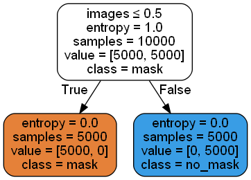

```python
dot_data = StringIO()
export_graphviz(d_model, out_file=dot_data,
                filled=True, rounded=True,
                special_characters=True, feature_names = ['images'],class_names=['mask','no_mask'])
graph = pydotplus.graph_from_dot_data(dot_data.getvalue())
graph.write_png('facemaskdetect.png')
Image(graph.create_png())
```

## Conclusion

This model is not optimal for classification. Decision trees are easy to interpret and visualize. They can easily capture Non-linear patterns in the data and require less data preprocessing than the other models; for example, there is no need to normalize. It can be used for feature engineering, such as predicting missing values, suitable for variable selection. It has no assumptions about distribution because of the non-parametric nature of the algorithm.  
However, decision tree models are sensitive to noise in data and can easily overfit. Decision trees are biased when the dataset is imbalanced—slight variations in the data.

# XGBoost Classification

Using the previously transformed dataset.  
Usually, to use XGBoost on a dataset with categorical features, we may want to consider applying some encoding (like one-hot encoding) before training the model. Also, if there were missing values, we could let the XGBoost handle them or devise a proper treatment.

```python
import xgboost as xgb
from xgboost import plot_tree
from sklearn.metrics import mean_squared_error
```

```python
d_train_data.info()
```

```
<class 'pandas.core.frame.DataFrame'>
RangeIndex: 10000 entries, 0 to 9999
Data columns (total 2 columns):
 #   Column  Non-Null Count  Dtype
---  ------  --------------  -----
 0   images  10000 non-null  int64
 1   label   10000 non-null  object
dtypes: int64(1), object(1)
memory usage: 156.4+ KB
```

```python
x_train_data = d_train_data.replace(["mask", "no_mask"], [0, 1])
x_val_data = d_val_data.replace(["no_mask", "mask"], [1, 0])
```

```python
X_train_xg = x_train_data[['images']].values
X_test_xg = x_val_data[['images']].values
y_train_xg = x_train_data['label'].values
y_test_xg = x_val_data['label'].values
```

### Building the model

```python
x_model = xgb.XGBRegressor(objective ='binary:logistic', colsample_bytree = 0.3, learning_rate = 0.1, max_depth = 3, alpha = 10, n_estimators = 10)
```

### Fit the regressor to the training set and make predictions on the test set using the familiar .fit() and .predict() methods.

```python
x_model.fit(X_train_xg, y_train_xg)

preds = x_model.predict(X_test_xg)
```

```
[22:12:58] WARNING: ..\src\learner.cc:1061: Starting in XGBoost 1.3.0, the default evaluation metric used with the objective 'binary:logistic' was changed from 'error' to 'logloss'. Explicitly set eval_metric if you'd like to restore the old behavior.
```

```python
# Mean square error
rmse = np.sqrt(mean_squared_error(y_test_xg, preds))
print("RMSE: %f" % (rmse))
```

```
RMSE: 0.180682
```

### Visualize Boosting Trees and Feature Importance

```python
data_dmatrix = xgb.DMatrix(data=X_train_xg,label=y_train_xg)
```

```python
params = {"objective":"binary:logistic",'colsample_bytree': 0.3,'learning_rate': 0.1,'max_depth': 3, 'alpha': 10}
xv_model = xgb.train(params=params, dtrain=data_dmatrix, num_boost_round=10)
```

```
[22:13:17] WARNING: ..\src\learner.cc:1061: Starting in XGBoost 1.3.0, the default evaluation metric used with the objective 'binary:logistic' was changed from 'error' to 'logloss'. Explicitly set eval_metric if you'd like to restore the old behavior.
```

### Plotting the first tree with the matplotlib library

```python
plot_tree(xv_model, num_trees=0)
plt.rcParams['figure.figsize'] = [50, 20]
plt.show()
```

[output not shown]

These plots provide insight into how the model arrived at its final decisions and what splits it made to arrive at those decisions.

```python
xgb.plot_importance(xv_model)
plt.rcParams['figure.figsize'] = [10, 10]
plt.show()
```

[figure not shown]

Obviously, since we only had one feature, it has the highest importance score.

## Conclusion

We transformed our dataset and applied XGBoost. This model is not appropriate for our use case since we only have a single feature.  
XGBoost is usually used when you have a large number of training samples, Greater than 1000 training samples, and less than 100 features. The number of features < number of training samples(Which is not our case) You have a mixture of categorical and numeric features Or just numeric attributes.

# References

1. Decision Tree Classification in Python, Avinash Navlani, https://www.datacamp.com/community/tutorials/decision-tree-classification-python
2. Using XGBoost in Python, Manish Pathak, https://www.datacamp.com/community/tutorials/xgboost-in-python
3. Extreme Gradient Boosting with XGBoost, Datacamp, https://learn.datacamp.com/courses/extreme-gradient-boosting-with-xgboost